# Regression og kunstig intelligens

## Indledning

Regression er en af de teknikker, der anvendes i kunstig intelligens. Vi ønsker i denne opgave at skabe en meget simpel kunstig intelligens, der kan forudsige strømforbruget i morgen i Danmark.

I dette datasæt ses strømforbrug per time for to hverdage for hele Danmark på fanen “2 dage”. Vi ønsker at bruge datasættet til at forudsige elforbruget dagen efter, så elselskaberne bedre kan planlægge energiproduktionen.

Vi har ikke en forventning om, at elforbruget følger en bestemt funktionstype, men forventer, at forbruget kan approksimeres med et polynomium af passende grad, hvor tidspunktet på dagen er den forklarende variabel.

Det er, indrømmet, nok en lidt naiv tanke, at elforbruget kan forudsiges alene ud fra én variabel, tid på dagen, der skulle nok flere variable i spil som f.eks. temperatur, nedbør, sol og vind, men vi holder os til den ene forklarende variabel her.

### Opgave 1

- Lav et punktplot af datasættet for de to døgn med 0-24 på x-aksen og forbruget på y-aksen.
- Overvej, hvilken tendens du ser i punktplottet, og dermed hvordan en fornuftig model kunne se ud.

### Opgave 2

- Lav lineær regression på datasættet.
- Lav desuden polynomiel regression med polynomier af grader fra 2 til 20.
- Hvilken regression vil du umiddelbart vurdere er bedst til vores formål?

Da vi ikke kender elforbruget i morgen, kan vi ikke sige, hvilken model der reelt er bedst. Det ved vi først, når i morgen er gået, og så er det jo for sent til vores formål.

Udfordringen er, at regressionen passer bedre til punkterne, når man bruger en højere grad, men at det ikke nødvendigvis derved kommer til at passe bedre til fremtidens forbrug. En lineær model passer sikkert meget dårligt, men laver heller ikke nogle vilde udsving mellem punkterne, hvor et polynomium af højere grad passer bedre til de kendte punkter, men kan svinge mere mellem punkterne, og dermed risikerer at passe ringere til fremtiden. Så det optimale er nok et polynomium, der rimeligt godt passer til kendte data, men ikke svinger for meget til at kunne passe på fremtidige data. Man taler om, at man ikke må overfitte sine data ved at bruge for høj en grad.

## Trænings- og testdata

Så vi må gøre noget andet end blot at lave regression på alle de kendte data for at skaffe en brugbar model. Ideen er, at vi deler datasættet i to dele.

**Træningsdata**: Den del som den kunstige intelligens skal bruge til at opstille modellen.

**Testdata**: Den del som den kunstige intelligens skal bruge til at vurdere, hvor god modelen er til at forudsige.

Vi vil bruge data for den første dag som træningsdata og data fra den anden dag som testdata.

### Opgave 3

- Vælg en grad mellem 2 og 20, og lav polynomiel regression på træningsdata (den første dag).

Hvis I er flere, så vælg gerne forskellige grader, så I efterfølgende kan sammenligne resultater. Hvis du er alene eller I ikke er så mange, så gentag opgave 3-5 for flere forskellige grader.

### Opgave 4

Det ses af testdata, at elforbruget på den anden dag kl. 12 er 4541 MWh.

Bemærk – modellen opstilles vha. træningsdata, men vurderes hva. testdata. Hvis modellen kan forudsige testdata rimeligt, håber vi, at den dermed også kan forudsige fremtidige dage rimeligt.

Det er nok klart, at det ikke er fornuftigt kun at se på afvigelsen kl. 12, men i stedet at se på afvigelserne for hele døgnet.

Som mål for, hvor god den kunstige intelligens er til at forudsige, vil vi benytte residualkvadratsummen for testdatasættet, som du allerede kender fra lineær regression.

Formlen er (SSE står for square-sum of errors):

$$\text{SSE} = \sum_{i=1}^n (y_i - f(x_i))^2$$

### Opgave 5

- Udregn SSE for din model fra opgave 3 anvendt på testdatasættet.
- Sammenlign SSE for modeller med forskellige grader, og vælg den model, der giver mindst SSE som bedst.
- Undersøg og forklar, hvad der sker med SSE, når graden bliver (for) stor.

Igen er det vigtigt at huske, at modellen laves vha. træningsdata, men den vurderes vha. testdata.

## Hvad er anderledes end sædvanlige regressionsopgaver?

I sædvanlige regressionsopgaver er modellen vigtig: Der er teoretiske overvejelser bag, hvilken model, der beskriver datasættet: lineær, eksponentiel, polynomiel m.v. I denne opgave er modellen ikke vigtig. Den er blot et middel til forudsigelsen af en talværdi, så der ligger ingen teoretisk eller kontekstbaseret forklaring bag den valgte model.

Desuden opdeles datasættet i træningsdata og testdata. I sædvanlige regressionsopgaver optræder kun ét datasæt, der svarer til træningsdata.

## Et større træningsdatasæt

Man kan ofte forbedre forudsigelserne ved at bruge et større datasæt. I datasættet ses strømforbrug per time for tre uger for hele Danmark på fanen “21 dage”.

### Opgave 6

- Anvend de første 20 dage som træningsdata til at opstille en model vha. et 6. grads polynomium.
- Vurder modellen i forhold til testdata for den sidste dag ved beregning af SSE.

### Opgave 7

- Brug siden eller lav selv beregningerne til at beregne SSE for alle grader fra 2 til 30.
- Vælg derefter modellen med lavest SSE som bedst.

Man kan også vælge at lade en større del af data være testdata end blot den ene dag.

### Opgave 8

- Brug siden med en anden inddeling end 20 dage til træningsdata og 1 dag til testdata, f.eks. 18 dage til træning og 3 dage til test.

## Lad os faktisk prøve at forudsige forbruget i morgen

Måske du allerede har bemærket, at den tredje fane i filen med data hedder “I morgen”. På siden kan du sammenligne din model med det faktiske forbrug “i morgen”.

### Opgave 9

- Se hvordan din model passer med forbruget i morgen, enten på siden eller ved selv at lave et plot af modellen sammen med punkterne for forbruget i morgen.

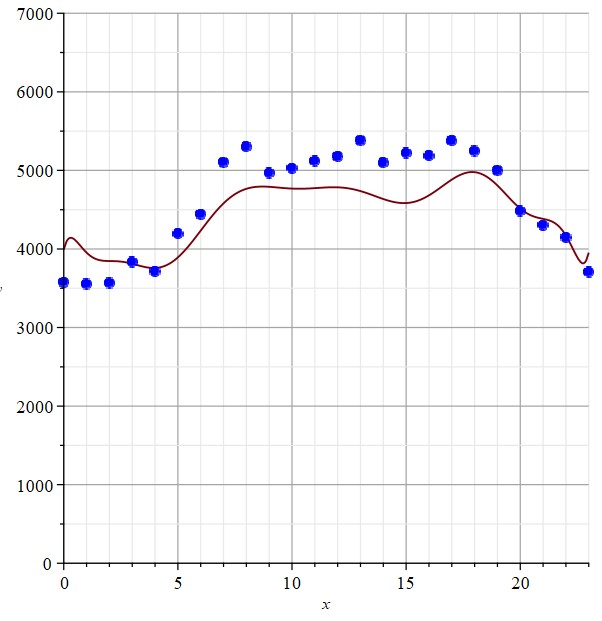

Forudsiglese af forbruget i morgen

Med dette er du kommet gennem principperne for at lave en simpel kunstig intelligens vha. polynomiel regression. De vigtigste principper handler om opdeling i trænings- og testdata, og i udfordringen med ikke at overfitte til træningsdata.

I eksemplet er der blot den éne forklarende variabel, som vi typisk arbejder med på gymnasieniveau, men sådanne modeller vil ofte i praksis indeholde flere forklarende variable, hvis de skal være mere præcise. Så de modeller, som eksperterne arbeder med for elforbrug og elpris er helt sikkert både mere komplicerede og mere præcise, end den simple tilgang, som vi har anvendt her.

Desuden er data i eksemplet med diskrete x-værdier (0, 1, 2 … 23), hvor der er andre sammenhænge kan være kontinuerte data, som giver endnu større risiko for at overfitte, hvis polynomiets grad bliver for stor.